# Predict Employee Attrition

Gaurav Mahajan

1/15/2021

linkedin profile: linkedin.com/in/mahajang

IBM is an American MNC operating in around 170 countries with major business vertical as computing, software, and hardware. Attrition is a major risk to service-providing organizations where trained and experienced people are the assets of the company. The organization would like to identify the factors which influence the attrition of employees.

Analysis Task:

1. Import attrition dataset
2. Exploratory data analysis a Find the age distribution of employees in IBM
2. Find outliers
3. Explore attrition by age
4. Explore data for Left employees
5. Find out the distribution of employees by the education field
6. Give a bar chart for the number of married and unmarried employees
3. Build up a logistic regression model to predict which employees are likely to attrite and find the significant variables

#Load Data

```r
library(readxl)
library(plyr) #cleaning
library(dplyr)
library(e1071)
library(caret)
```

```r
library(mlbench)
library(ggplot2)
library(tidyverse)
library(funModeling)
library(Hmisc)
library(car) #vif
library(tinytex)
library(pROC)
library(randomForest)
library(ROCR)
library(Metrics)
#Task 1: Load data

setwd("C:/OLD_LAPTOP/Gaurav/Purdue/4. Data Science with R/3. Practice_Projects/HR Attrition_IBM")
HR_data<- read_excel("C:/OLD_LAPTOP/Gaurav/Purdue/4. Data Science with R/3. Practice_Projects/HR Attrition_IBM/HR_Attrition_IBM_Data.xlsx")

dim(HR_data)
```

```
## [1] 1470   13
```

```r
names(HR_data)
```

```
##  [1] "Age"                     "Attrition"
##  [3] "Department"              "DistanceFromHome"
##  [5] "Education"               "EducationField"
##  [7] "EnvironmentSatisfaction" "JobSatisfaction"
##  [9] "MaritalStatus"           "MonthlyIncome"
## [11] "NumCompaniesWorked"      "WorkLifeBalance"
## [13] "YearsAtCompany"
```

```r
str(HR_data)
```

```
## tibble [1,470 x 13] (S3: tbl_df/tbl/data.frame)
##  $ Age                    : num [1:1470] 41 49 37 33 27 32 59 30 38 36 ...
##  $ Attrition              : chr [1:1470] "Yes" "No" "Yes" "No" ...
##  $ Department             : chr [1:1470] "Sales" "Research & Development" "Research & Development" "Research & Development" ...
##  $ DistanceFromHome       : num [1:1470] 1 8 2 3 2 2 3 24 23 27 ...
##  $ Education              : num [1:1470] 2 1 2 4 1 2 3 1 3 3 ...
##  $ EducationField         : chr [1:1470] "Life Sciences" "Life Sciences" "Other" "Life Sciences" ...
##  $ EnvironmentSatisfaction: num [1:1470] 2 3 4 4 1 4 3 4 4 3 ...
##  $ JobSatisfaction        : num [1:1470] 4 2 3 3 2 4 1 3 3 3 ...
##  $ MaritalStatus          : chr [1:1470] "Single" "Married" "Single" "Married" ...
##  $ MonthlyIncome          : num [1:1470] 5993 5130 2090 2909 3468 ...
##  $ NumCompaniesWorked     : num [1:1470] 8 1 6 1 9 0 4 1 0 6 ...
##  $ WorkLifeBalance        : num [1:1470] 1 3 3 3 3 2 2 3 3 2 ...
##  $ YearsAtCompany         : num [1:1470] 6 10 0 8 2 7 1 1 9 7 ...
```

```r
summary(HR_data)
```

```
##       Age         Attrition          Department        DistanceFromHome
##  Min.   :18.00   Length:1470        Length:1470        Min.   : 1.000
##  1st Qu.:30.00   Class :character   Class :character   1st Qu.: 2.000
##  Median :36.00   Mode  :character   Mode  :character   Median : 7.000
##  Mean   :36.92                                         Mean   : 9.193
##  3rd Qu.:43.00                                         3rd Qu.:14.000
##  Max.   :60.00                                         Max.   :29.000
##    Education     EducationField     EnvironmentSatisfaction JobSatisfaction
##  Min.   :1.000   Length:1470        Min.   :1.000           Min.   :1.000
##  1st Qu.:2.000   Class :character   1st Qu.:2.000           1st Qu.:2.000
##  Median :3.000   Mode  :character   Median :3.000           Median :3.000
##  Mean   :2.913                      Mean   :2.722           Mean   :2.729
##  3rd Qu.:4.000                      3rd Qu.:4.000           3rd Qu.:4.000
##  Max.   :5.000                      Max.   :4.000           Max.   :4.000
##  MaritalStatus      MonthlyIncome   NumCompaniesWorked WorkLifeBalance
##  Length:1470        Min.   : 1009   Min.   :0.000      Min.   :1.000
##  Class :character   1st Qu.: 2911   1st Qu.:1.000      1st Qu.:2.000
##  Mode  :character   Median : 4919   Median :2.000      Median :3.000
##                     Mean   : 6503   Mean   :2.693      Mean   :2.761
##                     3rd Qu.: 8379   3rd Qu.:4.000      3rd Qu.:3.000
##                     Max.   :19999   Max.   :9.000      Max.   :4.000
##  YearsAtCompany
##  Min.   : 0.000
##  1st Qu.: 3.000
##  Median : 5.000
##  Mean   : 7.008
##  3rd Qu.: 9.000
##  Max.   :40.000
```

```r
# View(HR_data)
```

Convert Character variables to Categorical and Integer variables:

```r
HR_data$Attrition<- as.factor(HR_data$Attrition)
HR_data$Department<- as.factor(HR_data$Department)
HR_data$Education<- as.integer(HR_data$Education)
HR_data$EducationField<- as.factor(HR_data$EducationField)
HR_data$EnvironmentSatisfaction<- as.integer(HR_data$EnvironmentSatisfaction)
HR_data$JobSatisfaction<- as.integer(HR_data$JobSatisfaction)
HR_data$MaritalStatus<- as.factor(HR_data$MaritalStatus)
HR_data$NumCompaniesWorked<- as.integer(HR_data$NumCompaniesWorked)
HR_data$WorkLifeBalance<- as.integer(HR_data$WorkLifeBalance)
HR_data$YearsAtCompany<- as.integer(HR_data$YearsAtCompany)

str(HR_data)
```

```
## tibble [1,470 x 13] (S3: tbl_df/tbl/data.frame)
##  $ Age                    : num [1:1470] 41 49 37 33 27 32 59 30 38 36 ...
##  $ Attrition              : Factor w/ 2 levels "No","Yes": 2 1 2 1 1 1 1 1 1 1 ...
##  $ Department             : Factor w/ 3 levels "Human Resources",..: 3 2 2 2 2 2 2 2 2 2 ...
##  $ DistanceFromHome       : num [1:1470] 1 8 2 3 2 2 3 24 23 27 ...
##  $ Education              : int [1:1470] 2 1 2 4 1 2 3 1 3 3 ...
##  $ EducationField         : Factor w/ 6 levels "Human Resources",..: 2 2 5 2 4 2 4 2 2 4 ...
##  $ EnvironmentSatisfaction: int [1:1470] 2 3 4 4 1 4 3 4 4 3 ...
##  $ JobSatisfaction        : int [1:1470] 4 2 3 3 2 4 1 3 3 3 ...
##  $ MaritalStatus          : Factor w/ 3 levels "Divorced","Married",..: 3 2 3 2 2 3 2 1 3 2 ...
##  $ MonthlyIncome          : num [1:1470] 5993 5130 2090 2909 3468 ...
##  $ NumCompaniesWorked     : int [1:1470] 8 1 6 1 9 0 4 1 0 6 ...
##  $ WorkLifeBalance        : int [1:1470] 1 3 3 3 3 2 2 3 3 2 ...
##  $ YearsAtCompany         : int [1:1470] 6 10 0 8 2 7 1 1 9 7 ...
```

```r
summary(HR_data)
```

```
##       Age        Attrition                   Department  DistanceFromHome
##  Min.   :18.00   No :1233   Human Resources       : 63   Min.   : 1.000
##  1st Qu.:30.00   Yes: 237   Research & Development:961   1st Qu.: 2.000
##  Median :36.00              Sales                 :446   Median : 7.000
##  Mean   :36.92                                           Mean   : 9.193
##  3rd Qu.:43.00                                           3rd Qu.:14.000
##  Max.   :60.00                                           Max.   :29.000
##    Education              EducationField EnvironmentSatisfaction
##  Min.   :1.000   Human Resources : 27    Min.   :1.000
##  1st Qu.:2.000   Life Sciences   :606    1st Qu.:2.000
##  Median :3.000   Marketing       :159    Median :3.000
##  Mean   :2.913   Medical         :464    Mean   :2.722
##  3rd Qu.:4.000   Other           : 82    3rd Qu.:4.000
##  Max.   :5.000   Technical Degree:132    Max.   :4.000
##  JobSatisfaction  MaritalStatus MonthlyIncome   NumCompaniesWorked
##  Min.   :1.000   Divorced:327   Min.   : 1009   Min.   :0.000
##  1st Qu.:2.000   Married :673   1st Qu.: 2911   1st Qu.:1.000
##  Median :3.000   Single  :470   Median : 4919   Median :2.000
##  Mean   :2.729                  Mean   : 6503   Mean   :2.693
##  3rd Qu.:4.000                  3rd Qu.: 8379   3rd Qu.:4.000
##  Max.   :4.000                  Max.   :19999   Max.   :9.000
##  WorkLifeBalance YearsAtCompany
##  Min.   :1.000   Min.   : 0.000
##  1st Qu.:2.000   1st Qu.: 3.000
##  Median :3.000   Median : 5.000
##  Mean   :2.761   Mean   : 7.008
##  3rd Qu.:3.000   3rd Qu.: 9.000
##  Max.   :4.000   Max.   :40.000
```

```r
HR_data<- as.data.frame(HR_data)
```

Task 2 (a) - Age ditribution of Employees:

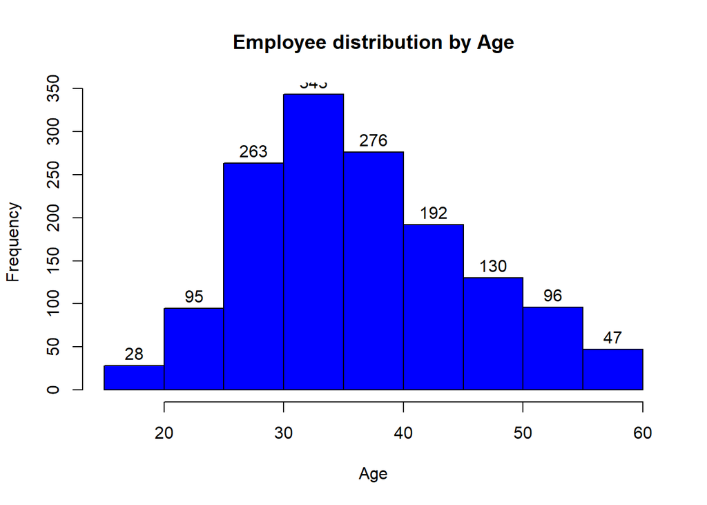

```r
Age_dist<- hist(HR_data$Age, col = 'blue', breaks=10, labels = TRUE,
                main ="Employee distribution by Age",
                xlab = "Age", ylab = "Frequency")
```

```r
Age_dist
```

```
## $breaks
##  [1] 15 20 25 30 35 40 45 50 55 60
##
## $counts
## [1]  28  95 263 343 276 192 130  96  47
##
## $density
## [1] 0.003809524 0.012925170 0.035782313 0.046666667 0.037551020 0.026122449
## [7] 0.017687075 0.013061224 0.006394558
##
## $mids
## [1] 17.5 22.5 27.5 32.5 37.5 42.5 47.5 52.5 57.5
##
## $xname
## [1] "HR_data$Age"
##
## $equidist
## [1] TRUE
##
## attr(,"class")
## [1] "histogram"
```

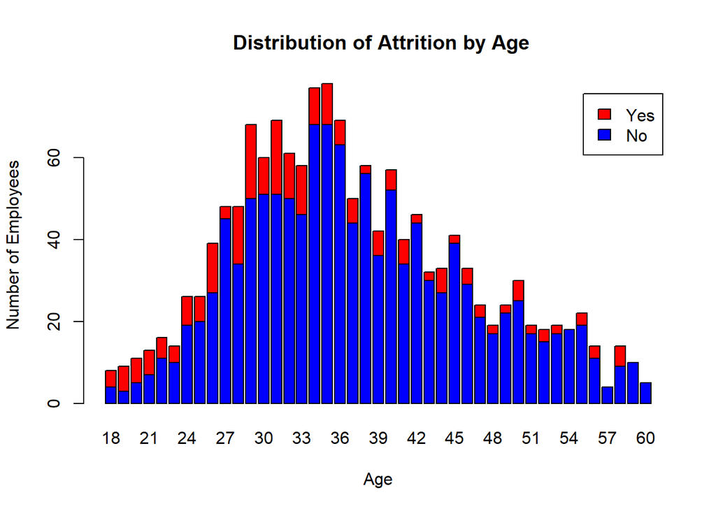

```r
Age_Attr_Dist<- table(HR_data$Attrition,HR_data$Age)
barplot(Age_Attr_Dist,legend=c("No","Yes"),main=" Distribution of Attrition by Age",
        xlab= "Age",ylab="Number of Employees", col=c('blue','red'))
```

Insights: ~60% (882) of the Total employees (1470) are between 25-40 age group

Task 2(b) - Find outliers :

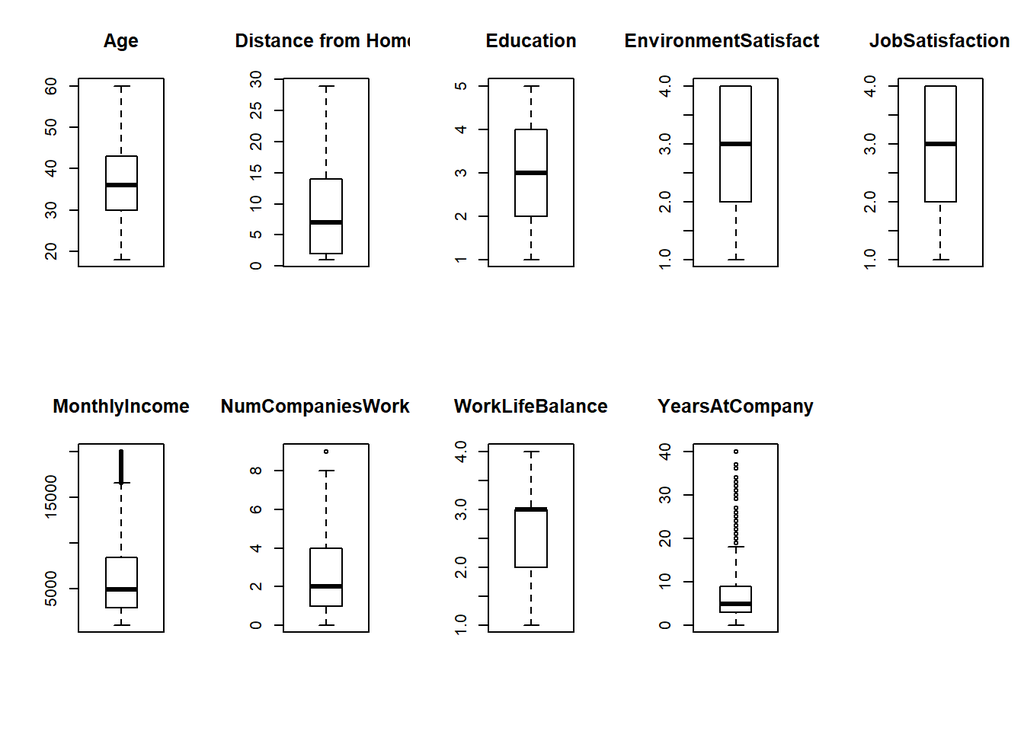

```r
par(mfrow=c(2,5))
OutAge<- boxplot(HR_data$Age, main="Age")
OutDistance<- boxplot(HR_data$DistanceFromHome, main="Distance from Home")
OutEdu<- boxplot(HR_data$Education, main="Education")
OutEnv<- boxplot(HR_data$EnvironmentSatisfaction, main="EnvironmentSatisfaction")
OutJobsat<- boxplot(HR_data$JobSatisfaction, main="JobSatisfaction")
OutMonthlyIncome<- boxplot(HR_data$MonthlyIncome, main="MonthlyIncome")
OutNumCoWrkd<- boxplot(HR_data$NumCompaniesWorked, main="NumCompaniesWorked")
OutWlbal<- boxplot(HR_data$WorkLifeBalance, main="WorkLifeBalance")
OutYrsAtCo<- boxplot(HR_data$YearsAtCompany, main="YearsAtCompany")
```

Insights: 1. There are outliers in following variables :  
2. Lot of Outliers present in Monthly Income and Years at Company 3. Few Outliers present in Number of COmpanies worked